# Trajectoires professionnelles

Faisabilité individuelle et séquences alternatives de présence des établissements

Auteur·rice

Projet DEPP A5 Mobilité des personnels

Date de publication

22 septembre 2026

**ImportantConclusion scientifique**

Les trajectoires **professionnelles individuelles** ne sont pas observables dans les données ouvertes acquises. Il n’existe ni identifiant personnel stable, ni état professionnel individuel annuel, ni fonction individuelle, ni motif d’entrée ou de sortie. La profondeur maximale est de deux années au niveau UAI.

Les exemples `Stable → Stable → Stable`, `Stable → Mobilité → Stable` et `Stable → Stable → Sortie` ne sont donc ni calculés ni simulés comme résultats réels. Ils nécessiteraient au minimum trois dates par personne.

# 1 Faisabilité des trajectoires professionnelles

Audit des objets longitudinaux demandés

| OBJET | DONNEES_REQUISES | DISPONIBILITE | DECISION | JUSTIFICATION |
| --- | --- | --- | --- | --- |
| Séquences professionnelles | Identifiant personnel et état répété sur au moins trois dates | NON DISPONIBLE | NON CONSTRUIT | Aucun identifiant personnel public; deux années seulement au niveau UAI |
| Durée dans un état professionnel | Dates d'entrée et de sortie de chaque état individuel | NON DISPONIBLE | NON CONSTRUIT | Aucune date d'état individuel |
| Transitions professionnelles | État individuel comparable en t et t+1 | NON DISPONIBLE | NON CONSTRUIT | Les variations d'ETP ne révèlent pas les mouvements individuels |
| Matrice de transition professionnelle | Transitions individuelles observées | NON DISPONIBLE | NON CONSTRUIT | Une matrice agrégée ne serait pas une matrice de carrières |
| Trajectoires professionnelles fréquentes | Séquences individuelles complètes | NON DISPONIBLE | NON CONSTRUIT | Stable → Mobilité → Stable exige trois dates individuelles |
| Profils de parcours individuels | Covariables et séquences individuelles | NON DISPONIBLE | NON CONSTRUIT | Le biais écologique interdit de transformer un profil d'établissement en profil de personne |

Conclusion : les microdonnées individuelles sécurisées du panel BSA seraient nécessaires.

# 2 Stratégie alternative

L’alternative décrit exclusivement la présence des **établissements** dans les fichiers du premier degré entre 2024 et 2025. Trois séquences sont observables :

- `OBSERVE → OBSERVE` ;
- `OBSERVE → ABSENT_DU_FICHIER` ;
- `ABSENT_DU_FICHIER → OBSERVE`.

Une absence du fichier n’est pas un état professionnel. Elle peut résulter d’une fermeture, d’une ouverture, d’un changement d’identifiant, d’un changement de champ ou d’un défaut de couverture.

# 3 Séquences fréquentes

| Séquence de présence | UAI | Part des UAI | Durée observée médiane | ETP initial médian | ETP final médian | Variation médiane | Part EP |
| --- | --- | --- | --- | --- | --- | --- | --- |
| OBSERVE → OBSERVE | 46 993,0 | 98.74% | 2,0 | 5,2 | 5,2 | 0,0 | 13.91% |
| OBSERVE → ABSENT_DU_FICHIER | 514,0 | 1.08% | 1,0 | 3,0 | NA | NA | 10.71% |
| ABSENT_DU_FICHIER → OBSERVE | 84,0 | 0.18% | 1,0 | NA | 7,4 | NA | 32.53% |

Source : DEPP, personnels du premier degré. Unité : établissement, jamais personnel.

Parmi 47 591 UAI observées au moins une fois, 46 993 (98,74 %) sont présentes aux deux dates, 514 (1,08 %) sont présentes seulement en 2024 et 84 (0,18 %) seulement en 2025. La variation médiane d’ETP des établissements présents aux deux dates est nulle. Ces constats ne renseignent pas les parcours des agents.

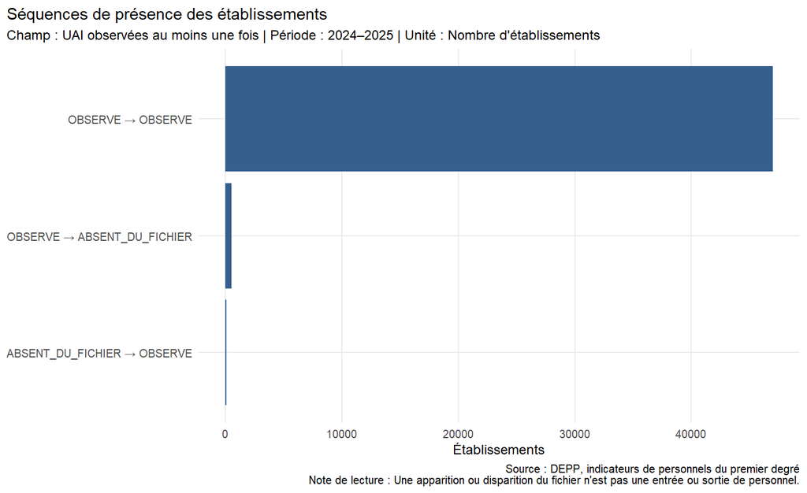

# 4 Durée dans les états

La seule durée calculable est le nombre d’années où une UAI est observée dans la fenêtre : une ou deux années. Elle est censurée à gauche pour les UAI présentes en 2024 et à droite pour celles présentes en 2025. Elle ne mesure ni la durée d’un poste, ni l’ancienneté professionnelle, ni le temps avant mobilité.

Avec deux dates seulement, aucune séquence à trois états et aucune durée complète ne sont identifiables.

# 5 Matrice de transition alternative

| Présence en 2024 | Présence en 2025 | UAI | Proportion conditionnelle |
| --- | --- | --- | --- |
| ABSENT_DU_FICHIER | OBSERVE | 84 | 100.00% |
| OBSERVE | ABSENT_DU_FICHIER | 514 | 1.08% |
| OBSERVE | OBSERVE | 46 993 | 98.92% |

Univers : UAI observées au moins une fois. La transition absent→absent est hors de l'univers et non observable.

Parmi les UAI observées en 2024, 98,92 % sont aussi observées en 2025 et 1,08 % ne le sont plus. Le taux de 100 % pour `ABSENT_DU_FICHIER → OBSERVE` résulte de la sélection de l’univers — une UAI absente en 2024 n’entre dans la base que si elle apparaît en 2025. Il ne s’agit donc pas d’un taux d’entrée.

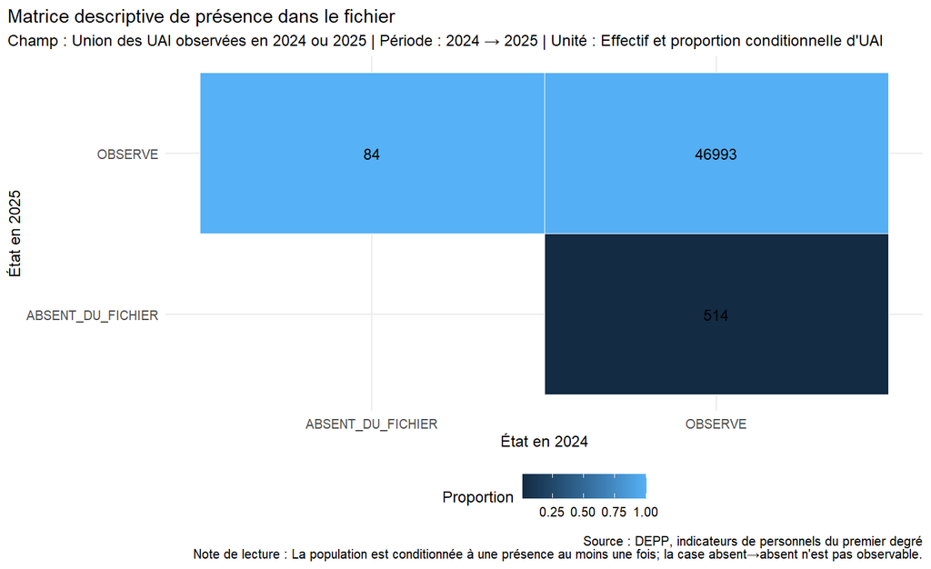

# 6 Profils de parcours

Les profils présentés sont des profils d’établissements selon leur séquence de présence. La part d’éducation prioritaire vaut 13,91 % pour les UAI présentes aux deux dates, 10,71 % pour les disparitions apparentes et 32,53 % pour les apparitions. Le dernier groupe ne comprend que 84 UAI et le statut EP provient du snapshot 2026. Ces écarts sont descriptifs, fragiles et non transposables aux personnels.

# 7 Description, association et causalité

Registre d'interprétation

| REGISTRE | QUESTION_AUTORISEE | INTERPRETATION | STATUT |
| --- | --- | --- | --- |
| Description | Combien d'UAI sont observées aux deux dates, apparaissent ou disparaissent du fichier ? | Présence dans le fichier et évolution d'ETP au niveau établissement | RÉALISÉ |
| Association | Aucune association de carrière estimée à cette étape; une association agrégée resterait écologique | Une corrélation entre caractéristiques d'établissement ne s'applique pas aux personnes | NON RÉALISÉ |
| Causalité | Aucune question causale n'est identifiable avec ces données | Ni effet du territoire, ni effet de l'éducation prioritaire, ni cause de mobilité | NON IDENTIFIABLE |

- **Description** : réalisée sur la présence des UAI et les ETP agrégés.
- **Association** : aucune association de trajectoire professionnelle n’est estimée ; une relation au niveau établissement resterait écologique.
- **Causalité** : aucun effet causal n’est identifié. Une différence descriptive ne démontre aucun effet du territoire ou de l’éducation prioritaire.

# 8 Validation

Validation des séquences alternatives

| INDICATEUR | RESULTAT | SEUIL | STATUT | ACTION |
| --- | --- | --- | --- | --- |
| Une ligne par UAI | 0 | 0 | OK | Aucune |
| Séquences autorisées | 0 | 0 | OK | Aucune |
| Total matrice | 0 | 0 | OK | Aucune |
| Profondeur temporelle | 2 | Au moins 3 pour les exemples conceptuels | LIMITE | Ne pas construire de séquence professionnelle à trois états |
| Aucune mobilité individuelle fabriquée | 0 | 0 | OK | Aucune |

Les contrôles garantissent une ligne par UAI, l’exhaustivité de la matrice, la restriction aux séquences autorisées et l’absence de variable individuelle fabriquée. La profondeur temporelle de deux observations reste une limite bloquante pour les trajectoires professionnelles demandées.